# Handout W02 — Język danych, pomiar i opis

Zarządzanie informacją — wzory i pytania do interpretacji

Marek Deja

2026/27

Handout zestawia miary opisowe czasu wyszukiwania na tych samych przykładach co pełny tekst wykładu W02; wnioskowanie o populacji rozwija wykład W03 (Losowość, estymacja i dwa tory wnioskowania).

# Jedna długa próba, kilka różnych miar

Seria A: 2, 4, 6, 8, 10 minut. Seria B: 2, 4, 6, 8, 30 minut. Serie różnią się wyłącznie ostatnią obserwacją. Przed odczytem tabeli przewidź, które miary reagują na wielkość ostatniej wartości, a które na uporządkowanie.

Tabela „Miary serii A i B” zestawia N, średnią, medianę, wariancję, SD, kwartyle, IQR, percentyl 90. i skośność $g_1$. Seria A: średnia 6, mediana 6, SD 3,16, IQR 4 minuty. Seria B: średnia 10, mediana 6, SD 11,40, IQR 4 minuty. Średnia i SD mają jednostkę minut, wariancja — minut kwadratowych.

Miary serii A i B (czasy w minutach, wariancja w minutach kwadratowych)

| Seria | N | Średnia | Mediana | Wariancja | SD | Q1 | Q3 | IQR | P90 | g1 |
| --- | --- | --- | --- | --- | --- | --- | --- | --- | --- | --- |
| A | 5 | 6,00 | 6,00 | 10,00 | 3,16 | 4,00 | 8,00 | 4,00 | 9,20 | 0,00 |
| B | 5 | 10,00 | 6,00 | 130,00 | 11,40 | 4,00 | 8,00 | 4,00 | 21,20 | 1,36 |

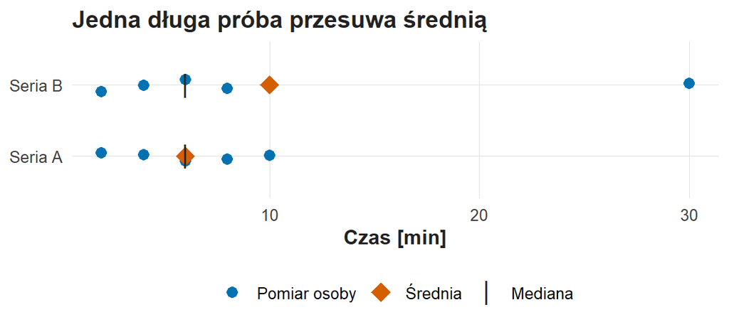

Jedna długa próba przesuwa średnią. Oś pozioma: czas w minutach; dwa wiersze: seria A i seria B. Koła oznaczają osoby, romb średnią, pionowa kreska medianę. W serii A romb i kreska leżą przy 6 minutach; w serii B kreska mediany leży przy 6 minutach, a romb średniej przy 10 minutach, na prawo od czterech kół między 2 a 8 minutami.

Notatka: ile osób w serii B ma czas bliski średniej 10 minut, a ile — czas nie dłuższy od mediany?

# Wzory czytane zdaniem

$$\bar{x}=\frac{\sum x_i}{n},\qquad
s=\sqrt{\frac{\sum(x_i-\bar{x})^2}{n-1}},\qquad
IQR=Q_3-Q_1,\qquad SE=\frac{s}{\sqrt{n}}.$$

Średnia jest sumą ważnych wartości podzieloną przez ich liczbę. SD opiera się na odległościach od średniej; duże odchylenia mają duży wkład przez podnoszenie do kwadratu. IQR jest szerokością środkowej połowy uporządkowanych wartości. SE opisuje precyzję średniej i maleje z pierwiastkiem z $n$: przy $s=3{,}16$ minuty SE wynosi 1,41 minuty dla $n=5$ i 0,26 minuty dla $n=150$.

$$\bar{x}_{\mathrm{ogółem}}=\frac{n_1\bar{x}_1+n_2\bar{x}_2}{n_1+n_2},
\qquad
\widehat F(c)=\frac{1}{n}\sum_{i=1}^{n}\mathbf{1}(x_i\leq c).$$

Pierwszy wzór łączy średnie grup z wagami równymi liczebnościom: 10 osób ze średnią 4 minuty i 30 osób ze średnią 8 minut dają 7 minut. Drugi wzór podaje udział ważnych pomiarów nieprzekraczających progu $c$; symbol $\mathbf{1}(\cdot)$ przyjmuje 1, gdy warunek jest spełniony. Dla serii B $\widehat F(8)=4/5=0{,}8$.

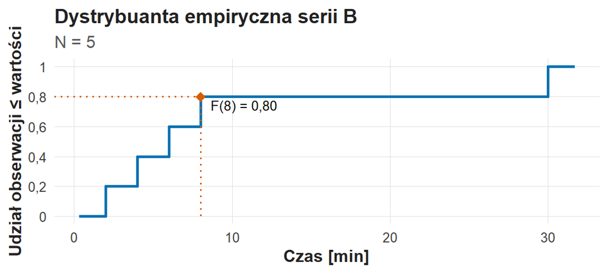

Dystrybuanta empiryczna serii B. Oś pozioma: czas w minutach; oś pionowa: udział obserwacji mniejszych lub równych wartości. Schodki rosną o 0,2 przy 2, 4, 6, 8 i 30 minutach; romb przy 8 minutach oznacza F(8) = 0,80.

Histogram czasu S02 ma przedziały po 2,5 minuty, zamknięte z prawej strony. Najwyższy słupek, 38 osób, stoi nad przedziałem od 5 do 7,5 minuty; prawy ogon sięga 33,8 minuty, a średnia 10,13 minuty przewyższa medianę 8,25 minuty.

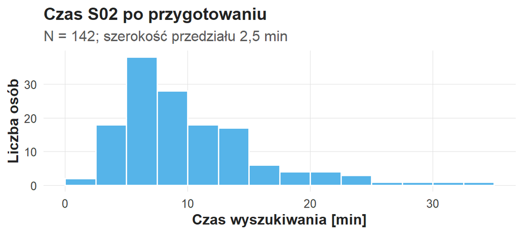

Czas S02 po przygotowaniu: histogram 142 ważnych czasów z przedziałami po 2,5 minuty. Oś pozioma: czas wyszukiwania w minutach; oś pionowa: liczba osób. Najwyższy słupek, 38 osób, stoi nad przedziałem od 5 do 7,5 minuty; słupki obniżają się w prawo aż do 33,8 minuty.

Miary i druga wielkość potrzebna w opisie

| Miara | Pytanie | Druga wielkość potrzebna w opisie |
| --- | --- | --- |
| Średnia | Jaka suma przypada na obserwację? | Mediana i SD: środek i rozrzut osób |
| Mediana | Gdzie leży środek uporządkowanych wartości? | Kwartyle: szerokość środkowej połowy |
| SD | Jak bardzo różnią się pomiary względem średniej? | SE $=s/\sqrt{n}$: precyzja średniej |
| IQR | Jak szeroka jest środkowa połowa rozkładu? | Przedział ufności: niepewność estymaty (W03) |
| Proporcja | Jaka część mianownika spełnia warunek? | Mianownik N |

# Odczyt indeksu

Niech $O_i$ oznacza zbiór ważnych pozycji osoby $i$, $m_i$ — ich liczbę, a $x^*_{ik}$ — odpowiedź na pozycję $k$ po ukierunkowaniu. Indeks obliczamy według:

$$I_i=\frac{1}{m_i}\sum_{k\in O_i}x^*_{ik}\quad\text{dla }m_i\geq5 .$$

Przy mniej niż pięciu ważnych odpowiedziach indeks jest brakiem. Pozycję 3 („Odczytanie rekordu wymaga ode mnie zgadywania.”) ukierunkowujemy wzorem $x^*=6-x$. Suma obejmuje wyłącznie ważne odpowiedzi, a dzielnikiem jest $m_i$: odpowiedzi 4, 5, NA, 4, 3, 5 dają $I_i=21/5=4{,}2$.

W S02 wynik to dydaktyczny indeks deklarowanej użyteczności katalogu i radzenia sobie z katalogiem. Każdy wniosek o związku indeksu z czasem lub powodzeniem używa pełnej nazwy indeksu; alfa Cronbacha opisuje spójność odpowiedzi, a trafność interpretacji wymaga dowodów z treści pozycji, rozumienia pytań i związków z innymi pomiarami.

# Pytania do notatek

1. Jakie dwa opisy doświadczenia użytkownika dają średnia i mediana serii B?
2. Jakie informacje o rekordzie rozstrzygają, czy punkt poza wąsem wykresu pudełkowego jest błędem?
3. Jak zmieniają się SE i SD czasu, gdy liczba osób rośnie z 5 do 142?
4. Jak odróżnisz ocenę filtrów (pozycja 2) od samooceny działania (pozycja 4) i od obserwowanego powodzenia?
5. Jaka konstrukcja pytania wielokrotnego wyboru wyjaśnia sumę odsetków respondentów powyżej 100%?

Na ćwiczeniu C03 (Portret próby) opisujemy czas i skuteczność, a na ćwiczeniu C04 (Od pozycji do konstruktu) — pozycje, regułę indeksu i mianowniki kanałów. Ramy DigComp 2.2 i ACRL oraz publikacja o ISS wspierają konstrukcję pytań; walidacja własnego narzędzia jest osobnym badaniem. Pełne odnośniki zawiera wykład.